# Risk Factor Analysis

## Outcome Variable

**Outcome Variable:** y_rate_wtkg

## Predictor Variables

**Intervention Variable:** nchldlt5

**Adjustment Set:**

- arm
- W_mage
- meducyrs
- feducyrs
- hhwealth_quart
- hfoodsec
- W_mhtcm
- W_mwtkg
- W_mbmi
- W_nrooms
- W_parity
- impfloor
- impsan
- safeh20
- delta_W_mage
- delta_meducyrs
- delta_feducyrs
- delta_hhwealth_quart
- delta_hfoodsec
- delta_W_mhtcm
- delta_W_mwtkg
- delta_W_mbmi
- delta_W_nrooms
- delta_W_parity
- delta_impfloor
- delta_impsan
- delta_safeh20

## Stratifying Variables

The analysis was stratified on these variable(s):

- agecat
- studyid
- country

## Data Summary

| agecat | studyid | country | nchldlt5 | n_cell | n |
| --- | --- | --- | --- | --- | --- |
| 0-3 months | IRC | INDIA | 1 | 87 | 394 |
| 0-3 months | IRC | INDIA | 2+ | 307 | 394 |
| 0-3 months | JiVitA-3 | BANGLADESH | 1 | 12682 | 20269 |
| 0-3 months | JiVitA-3 | BANGLADESH | 2+ | 7587 | 20269 |
| 0-3 months | NIH-Crypto | BANGLADESH | 1 | 516 | 725 |
| 0-3 months | NIH-Crypto | BANGLADESH | 2+ | 209 | 725 |
| 0-3 months | PROVIDE | BANGLADESH | 1 | 471 | 640 |
| 0-3 months | PROVIDE | BANGLADESH | 2+ | 169 | 640 |
| 0-3 months | TanzaniaChild2 | TANZANIA, UNITED REPUBLIC OF | 1 | 1380 | 2014 |
| 0-3 months | TanzaniaChild2 | TANZANIA, UNITED REPUBLIC OF | 2+ | 634 | 2014 |
| 3-6 months | IRC | INDIA | 1 | 87 | 399 |
| 3-6 months | IRC | INDIA | 2+ | 312 | 399 |
| 3-6 months | JiVitA-3 | BANGLADESH | 1 | 8194 | 12711 |
| 3-6 months | JiVitA-3 | BANGLADESH | 2+ | 4517 | 12711 |
| 3-6 months | NIH-Crypto | BANGLADESH | 1 | 498 | 702 |
| 3-6 months | NIH-Crypto | BANGLADESH | 2+ | 204 | 702 |
| 3-6 months | PROVIDE | BANGLADESH | 1 | 437 | 601 |
| 3-6 months | PROVIDE | BANGLADESH | 2+ | 164 | 601 |
| 3-6 months | TanzaniaChild2 | TANZANIA, UNITED REPUBLIC OF | 1 | 1151 | 1659 |
| 3-6 months | TanzaniaChild2 | TANZANIA, UNITED REPUBLIC OF | 2+ | 508 | 1659 |
| 6-9 months | IRC | INDIA | 1 | 89 | 410 |
| 6-9 months | IRC | INDIA | 2+ | 321 | 410 |
| 6-9 months | LCNI-5 | MALAWI | 1 | 260 | 554 |
| 6-9 months | LCNI-5 | MALAWI | 2+ | 294 | 554 |
| 6-9 months | NIH-Crypto | BANGLADESH | 1 | 491 | 693 |
| 6-9 months | NIH-Crypto | BANGLADESH | 2+ | 202 | 693 |
| 6-9 months | PROVIDE | BANGLADESH | 1 | 417 | 576 |
| 6-9 months | PROVIDE | BANGLADESH | 2+ | 159 | 576 |
| 6-9 months | TanzaniaChild2 | TANZANIA, UNITED REPUBLIC OF | 1 | 1040 | 1488 |
| 6-9 months | TanzaniaChild2 | TANZANIA, UNITED REPUBLIC OF | 2+ | 448 | 1488 |

[output cut: 54 more lines]

The following strata were considered:

- agecat: 0-3 months, studyid: IRC, country: INDIA
- agecat: 0-3 months, studyid: JiVitA-3, country: BANGLADESH
- agecat: 0-3 months, studyid: NIH-Crypto, country: BANGLADESH
- agecat: 0-3 months, studyid: PROVIDE, country: BANGLADESH
- agecat: 0-3 months, studyid: TanzaniaChild2, country: TANZANIA, UNITED REPUBLIC OF
- agecat: 12-15 months, studyid: iLiNS-Zinc, country: BURKINA FASO
- agecat: 12-15 months, studyid: IRC, country: INDIA
- agecat: 12-15 months, studyid: LCNI-5, country: MALAWI
- agecat: 12-15 months, studyid: NIH-Crypto, country: BANGLADESH
- agecat: 12-15 months, studyid: PROVIDE, country: BANGLADESH
- agecat: 12-15 months, studyid: TanzaniaChild2, country: TANZANIA, UNITED REPUBLIC OF
- agecat: 15-18 months, studyid: iLiNS-Zinc, country: BURKINA FASO
- agecat: 15-18 months, studyid: IRC, country: INDIA
- agecat: 15-18 months, studyid: LCNI-5, country: MALAWI
- agecat: 15-18 months, studyid: NIH-Crypto, country: BANGLADESH
- agecat: 15-18 months, studyid: PROVIDE, country: BANGLADESH
- agecat: 15-18 months, studyid: TanzaniaChild2, country: TANZANIA, UNITED REPUBLIC OF
- agecat: 18-21 months, studyid: IRC, country: INDIA
- agecat: 18-21 months, studyid: LCNI-5, country: MALAWI
- agecat: 18-21 months, studyid: NIH-Crypto, country: BANGLADESH
- agecat: 18-21 months, studyid: PROVIDE, country: BANGLADESH
- agecat: 18-21 months, studyid: TanzaniaChild2, country: TANZANIA, UNITED REPUBLIC OF
- agecat: 21-24 months, studyid: IRC, country: INDIA
- agecat: 21-24 months, studyid: LCNI-5, country: MALAWI
- agecat: 21-24 months, studyid: NIH-Crypto, country: BANGLADESH
- agecat: 21-24 months, studyid: PROVIDE, country: BANGLADESH
- agecat: 3-6 months, studyid: IRC, country: INDIA
- agecat: 3-6 months, studyid: JiVitA-3, country: BANGLADESH
- agecat: 3-6 months, studyid: NIH-Crypto, country: BANGLADESH
- agecat: 3-6 months, studyid: PROVIDE, country: BANGLADESH
- agecat: 3-6 months, studyid: TanzaniaChild2, country: TANZANIA, UNITED REPUBLIC OF
- agecat: 6-9 months, studyid: IRC, country: INDIA
- agecat: 6-9 months, studyid: LCNI-5, country: MALAWI
- agecat: 6-9 months, studyid: NIH-Crypto, country: BANGLADESH
- agecat: 6-9 months, studyid: PROVIDE, country: BANGLADESH
- agecat: 6-9 months, studyid: TanzaniaChild2, country: TANZANIA, UNITED REPUBLIC OF
- agecat: 9-12 months, studyid: iLiNS-Zinc, country: BURKINA FASO
- agecat: 9-12 months, studyid: IRC, country: INDIA
- agecat: 9-12 months, studyid: LCNI-5, country: MALAWI
- agecat: 9-12 months, studyid: NIH-Crypto, country: BANGLADESH
- agecat: 9-12 months, studyid: PROVIDE, country: BANGLADESH
- agecat: 9-12 months, studyid: TanzaniaChild2, country: TANZANIA, UNITED REPUBLIC OF

### Dropped Strata

Some strata were dropped due to rare outcomes:

- agecat: 18-21 months, studyid: TanzaniaChild2, country: TANZANIA, UNITED REPUBLIC OF

## Methods Detail

We’re interested in the causal parameters $E[Y_a]$ for all values of $a \in \mathcal{A}$. These parameters represent the mean outcome if, possibly contrary to fact, we intervened to set all units to have $A=a$. Under the randomization and positivity assumptions, these are identified by the statistical parameters $\psi_a=E_W[E_{Y|A,W}(Y|A=a,W)]$. In addition, we’re interested in the mean of $Y$, $E[Y]$ under no intervention (the observed mean). We will estimate these parameters by using SuperLearner to fit the relevant likelihood factors – $E_{Y|A,W}(Y|A=a,W)$ and $p(A=a|W)$, and then updating our likelihood fit using a joint TMLE.

For unadjusted analyses ($W=\{\}$), initial likelihoods were estimated using Lrnr_glm to estimate the simple $E(Y|A)$ and Lrnr_mean to estimate $p(A)$. For adjusted analyses, a small library containing Lrnr_glmnet, Lrnr_xgboost, and Lrnr_mean was used.

Having estimated these parameters, we will then use the delta method to estimate relative risks and attributable risks relative to a prespecified baseline level of $A$.

# Results Detail

## Results Plots

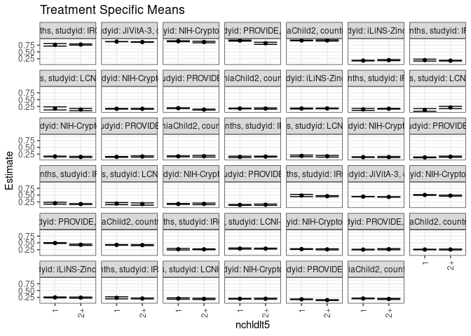

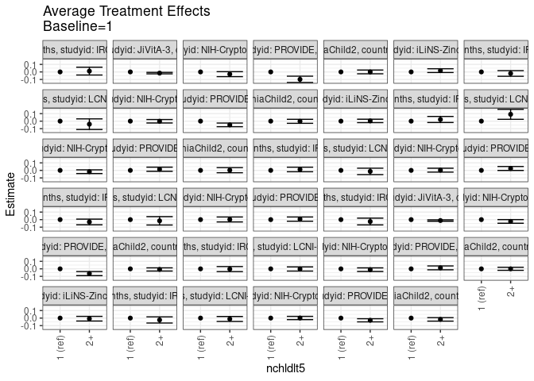

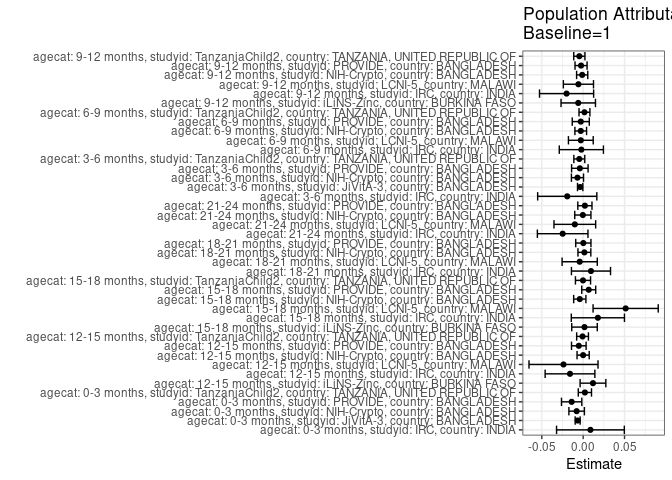

## Results Table

### Parameter: TSM

| agecat | studyid | country | intervention_level | baseline_level | estimate | ci_lower | ci_upper |
| --- | --- | --- | --- | --- | --- | --- | --- |
| 0-3 months | IRC | INDIA | 1 | NA | 0.7591909 | 0.7123262 | 0.8060556 |
| 0-3 months | IRC | INDIA | 2+ | NA | 0.7700401 | 0.7484710 | 0.7916092 |
| 0-3 months | JiVitA-3 | BANGLADESH | 1 | NA | 0.8776942 | 0.8733024 | 0.8820860 |
| 0-3 months | JiVitA-3 | BANGLADESH | 2+ | NA | 0.8619767 | 0.8528572 | 0.8710961 |
| 0-3 months | NIH-Crypto | BANGLADESH | 1 | NA | 0.8923995 | 0.8750232 | 0.9097759 |
| 0-3 months | NIH-Crypto | BANGLADESH | 2+ | NA | 0.8626159 | 0.8343097 | 0.8909222 |
| 0-3 months | PROVIDE | BANGLADESH | 1 | NA | 0.9155717 | 0.8966235 | 0.9345199 |
| 0-3 months | PROVIDE | BANGLADESH | 2+ | NA | 0.8170068 | 0.7795038 | 0.8545099 |
| 0-3 months | TanzaniaChild2 | TANZANIA, UNITED REPUBLIC OF | 1 | NA | 0.9202853 | 0.9071273 | 0.9334434 |
| 0-3 months | TanzaniaChild2 | TANZANIA, UNITED REPUBLIC OF | 2+ | NA | 0.9201759 | 0.8990501 | 0.9413017 |
| 3-6 months | IRC | INDIA | 1 | NA | 0.4853142 | 0.4448470 | 0.5257813 |
| 3-6 months | IRC | INDIA | 2+ | NA | 0.4601675 | 0.4405783 | 0.4797566 |
| 3-6 months | JiVitA-3 | BANGLADESH | 1 | NA | 0.4450136 | 0.4404235 | 0.4496037 |
| 3-6 months | JiVitA-3 | BANGLADESH | 2+ | NA | 0.4329638 | 0.4242271 | 0.4417005 |
| 3-6 months | NIH-Crypto | BANGLADESH | 1 | NA | 0.5049251 | 0.4912525 | 0.5185977 |
| 3-6 months | NIH-Crypto | BANGLADESH | 2+ | NA | 0.4808568 | 0.4608585 | 0.5008551 |
| 3-6 months | PROVIDE | BANGLADESH | 1 | NA | 0.4930818 | 0.4789592 | 0.5072045 |
| 3-6 months | PROVIDE | BANGLADESH | 2+ | NA | 0.4301848 | 0.4070472 | 0.4533225 |
| 3-6 months | TanzaniaChild2 | TANZANIA, UNITED REPUBLIC OF | 1 | NA | 0.4242520 | 0.4130065 | 0.4354975 |
| 3-6 months | TanzaniaChild2 | TANZANIA, UNITED REPUBLIC OF | 2+ | NA | 0.4164880 | 0.3983997 | 0.4345762 |
| 6-9 months | IRC | INDIA | 1 | NA | 0.2648147 | 0.2354826 | 0.2941468 |
| 6-9 months | IRC | INDIA | 2+ | NA | 0.2618720 | 0.2459384 | 0.2778055 |
| 6-9 months | LCNI-5 | MALAWI | 1 | NA | 0.2881685 | 0.2675108 | 0.3088261 |
| 6-9 months | LCNI-5 | MALAWI | 2+ | NA | 0.2863127 | 0.2685598 | 0.3040657 |
| 6-9 months | NIH-Crypto | BANGLADESH | 1 | NA | 0.2704383 | 0.2575259 | 0.2833507 |
| 6-9 months | NIH-Crypto | BANGLADESH | 2+ | NA | 0.2595993 | 0.2394152 | 0.2797833 |
| 6-9 months | PROVIDE | BANGLADESH | 1 | NA | 0.2520570 | 0.2389115 | 0.2652026 |
| 6-9 months | PROVIDE | BANGLADESH | 2+ | NA | 0.2652363 | 0.2431652 | 0.2873075 |
| 6-9 months | TanzaniaChild2 | TANZANIA, UNITED REPUBLIC OF | 1 | NA | 0.2542775 | 0.2426559 | 0.2658992 |
| 6-9 months | TanzaniaChild2 | TANZANIA, UNITED REPUBLIC OF | 2+ | NA | 0.2550207 | 0.2381291 | 0.2719123 |

[output cut: 52 more lines]

### Parameter: E(Y)

| agecat | studyid | country | intervention_level | baseline_level | estimate | ci_lower | ci_upper |
| --- | --- | --- | --- | --- | --- | --- | --- |
| 0-3 months | IRC | INDIA | NA | NA | 0.7679906 | 0.7485485 | 0.7874326 |
| 0-3 months | JiVitA-3 | BANGLADESH | NA | NA | 0.8710452 | 0.8679657 | 0.8741247 |
| 0-3 months | NIH-Crypto | BANGLADESH | NA | NA | 0.8845220 | 0.8699746 | 0.8990694 |
| 0-3 months | PROVIDE | BANGLADESH | NA | NA | 0.9016472 | 0.8868914 | 0.9164029 |
| 0-3 months | TanzaniaChild2 | TANZANIA, UNITED REPUBLIC OF | NA | NA | 0.9223779 | 0.9122086 | 0.9325472 |
| 3-6 months | IRC | INDIA | NA | NA | 0.4660717 | 0.4485044 | 0.4836390 |
| 3-6 months | JiVitA-3 | BANGLADESH | NA | NA | 0.4414051 | 0.4384353 | 0.4443748 |
| 3-6 months | NIH-Crypto | BANGLADESH | NA | NA | 0.4980544 | 0.4869892 | 0.5091196 |
| 3-6 months | PROVIDE | BANGLADESH | NA | NA | 0.4890611 | 0.4760060 | 0.5021163 |
| 3-6 months | TanzaniaChild2 | TANZANIA, UNITED REPUBLIC OF | NA | NA | 0.4195871 | 0.4109053 | 0.4282689 |
| 6-9 months | IRC | INDIA | NA | NA | 0.2626310 | 0.2487635 | 0.2764985 |
| 6-9 months | LCNI-5 | MALAWI | NA | NA | 0.2853462 | 0.2727187 | 0.2979736 |
| 6-9 months | NIH-Crypto | BANGLADESH | NA | NA | 0.2675097 | 0.2569518 | 0.2780676 |
| 6-9 months | PROVIDE | BANGLADESH | NA | NA | 0.2491653 | 0.2371134 | 0.2612172 |
| 6-9 months | TanzaniaChild2 | TANZANIA, UNITED REPUBLIC OF | NA | NA | 0.2558522 | 0.2469636 | 0.2647409 |
| 9-12 months | iLiNS-Zinc | BURKINA FASO | NA | NA | 0.2420700 | 0.2289407 | 0.2551993 |
| 9-12 months | IRC | INDIA | NA | NA | 0.2132244 | 0.1989917 | 0.2274571 |
| 9-12 months | LCNI-5 | MALAWI | NA | NA | 0.2022567 | 0.1863082 | 0.2182053 |
| 9-12 months | NIH-Crypto | BANGLADESH | NA | NA | 0.1978449 | 0.1874487 | 0.2082411 |
| 9-12 months | PROVIDE | BANGLADESH | NA | NA | 0.1775316 | 0.1681968 | 0.1868664 |
| 9-12 months | TanzaniaChild2 | TANZANIA, UNITED REPUBLIC OF | NA | NA | 0.2046179 | 0.1945139 | 0.2147219 |
| 12-15 months | iLiNS-Zinc | BURKINA FASO | NA | NA | 0.1921946 | 0.1813846 | 0.2030045 |
| 12-15 months | IRC | INDIA | NA | NA | 0.1821426 | 0.1693469 | 0.1949383 |
| 12-15 months | LCNI-5 | MALAWI | NA | NA | 0.1530519 | 0.1191456 | 0.1869583 |
| 12-15 months | NIH-Crypto | BANGLADESH | NA | NA | 0.1640603 | 0.1535198 | 0.1746008 |
| 12-15 months | PROVIDE | BANGLADESH | NA | NA | 0.1800324 | 0.1683272 | 0.1917375 |
| 12-15 months | TanzaniaChild2 | TANZANIA, UNITED REPUBLIC OF | NA | NA | 0.1737296 | 0.1623947 | 0.1850645 |
| 15-18 months | iLiNS-Zinc | BURKINA FASO | NA | NA | 0.1750401 | 0.1647066 | 0.1853735 |
| 15-18 months | IRC | INDIA | NA | NA | 0.1604586 | 0.1468913 | 0.1740260 |
| 15-18 months | LCNI-5 | MALAWI | NA | NA | 0.1724751 | 0.1407874 | 0.2041628 |
| 15-18 months | NIH-Crypto | BANGLADESH | NA | NA | 0.1611973 | 0.1506617 | 0.1717329 |
| 15-18 months | PROVIDE | BANGLADESH | NA | NA | 0.1563514 | 0.1445823 | 0.1681205 |
| 15-18 months | TanzaniaChild2 | TANZANIA, UNITED REPUBLIC OF | NA | NA | 0.1702121 | 0.1559390 | 0.1844852 |
| 18-21 months | IRC | INDIA | NA | NA | 0.1589791 | 0.1455977 | 0.1723606 |
| 18-21 months | LCNI-5 | MALAWI | NA | NA | 0.1816953 | 0.1614502 | 0.2019405 |
| 18-21 months | NIH-Crypto | BANGLADESH | NA | NA | 0.1426609 | 0.1319333 | 0.1533885 |
| 18-21 months | PROVIDE | BANGLADESH | NA | NA | 0.1324882 | 0.1210438 | 0.1439326 |
| 21-24 months | IRC | INDIA | NA | NA | 0.1777340 | 0.1639174 | 0.1915507 |
| 21-24 months | LCNI-5 | MALAWI | NA | NA | 0.1772328 | 0.1503917 | 0.2040738 |
| 21-24 months | NIH-Crypto | BANGLADESH | NA | NA | 0.1750500 | 0.1624914 | 0.1876087 |
| 21-24 months | PROVIDE | BANGLADESH | NA | NA | 0.1419705 | 0.1305335 | 0.1534075 |

### Parameter: ATE

| agecat | studyid | country | intervention_level | baseline_level | estimate | ci_lower | ci_upper |
| --- | --- | --- | --- | --- | --- | --- | --- |
| 0-3 months | IRC | INDIA | 1 | 1 | 0.0000000 | 0.0000000 | 0.0000000 |
| 0-3 months | IRC | INDIA | 2+ | 1 | 0.0108492 | -0.0408825 | 0.0625810 |
| 0-3 months | JiVitA-3 | BANGLADESH | 1 | 1 | 0.0000000 | 0.0000000 | 0.0000000 |
| 0-3 months | JiVitA-3 | BANGLADESH | 2+ | 1 | -0.0157175 | -0.0256166 | -0.0058185 |
| 0-3 months | NIH-Crypto | BANGLADESH | 1 | 1 | 0.0000000 | 0.0000000 | 0.0000000 |
| 0-3 months | NIH-Crypto | BANGLADESH | 2+ | 1 | -0.0297836 | -0.0630027 | 0.0034355 |
| 0-3 months | PROVIDE | BANGLADESH | 1 | 1 | 0.0000000 | 0.0000000 | 0.0000000 |
| 0-3 months | PROVIDE | BANGLADESH | 2+ | 1 | -0.0985649 | -0.1405265 | -0.0566032 |
| 0-3 months | TanzaniaChild2 | TANZANIA, UNITED REPUBLIC OF | 1 | 1 | 0.0000000 | 0.0000000 | 0.0000000 |
| 0-3 months | TanzaniaChild2 | TANZANIA, UNITED REPUBLIC OF | 2+ | 1 | -0.0001094 | -0.0250716 | 0.0248527 |
| 3-6 months | IRC | INDIA | 1 | 1 | 0.0000000 | 0.0000000 | 0.0000000 |
| 3-6 months | IRC | INDIA | 2+ | 1 | -0.0251467 | -0.0701880 | 0.0198947 |
| 3-6 months | JiVitA-3 | BANGLADESH | 1 | 1 | 0.0000000 | 0.0000000 | 0.0000000 |
| 3-6 months | JiVitA-3 | BANGLADESH | 2+ | 1 | -0.0120498 | -0.0216836 | -0.0024160 |
| 3-6 months | NIH-Crypto | BANGLADESH | 1 | 1 | 0.0000000 | 0.0000000 | 0.0000000 |
| 3-6 months | NIH-Crypto | BANGLADESH | 2+ | 1 | -0.0240683 | -0.0482558 | 0.0001192 |
| 3-6 months | PROVIDE | BANGLADESH | 1 | 1 | 0.0000000 | 0.0000000 | 0.0000000 |
| 3-6 months | PROVIDE | BANGLADESH | 2+ | 1 | -0.0628970 | -0.0902108 | -0.0355832 |
| 3-6 months | TanzaniaChild2 | TANZANIA, UNITED REPUBLIC OF | 1 | 1 | 0.0000000 | 0.0000000 | 0.0000000 |
| 3-6 months | TanzaniaChild2 | TANZANIA, UNITED REPUBLIC OF | 2+ | 1 | -0.0077640 | -0.0291268 | 0.0135989 |
| 6-9 months | IRC | INDIA | 1 | 1 | 0.0000000 | 0.0000000 | 0.0000000 |
| 6-9 months | IRC | INDIA | 2+ | 1 | -0.0029427 | -0.0363685 | 0.0304830 |
| 6-9 months | LCNI-5 | MALAWI | 1 | 1 | 0.0000000 | 0.0000000 | 0.0000000 |
| 6-9 months | LCNI-5 | MALAWI | 2+ | 1 | -0.0018557 | -0.0294311 | 0.0257196 |
| 6-9 months | NIH-Crypto | BANGLADESH | 1 | 1 | 0.0000000 | 0.0000000 | 0.0000000 |
| 6-9 months | NIH-Crypto | BANGLADESH | 2+ | 1 | -0.0108390 | -0.0348160 | 0.0131380 |
| 6-9 months | PROVIDE | BANGLADESH | 1 | 1 | 0.0000000 | 0.0000000 | 0.0000000 |
| 6-9 months | PROVIDE | BANGLADESH | 2+ | 1 | 0.0131793 | -0.0123674 | 0.0387261 |
| 6-9 months | TanzaniaChild2 | TANZANIA, UNITED REPUBLIC OF | 1 | 1 | 0.0000000 | 0.0000000 | 0.0000000 |
| 6-9 months | TanzaniaChild2 | TANZANIA, UNITED REPUBLIC OF | 2+ | 1 | 0.0007432 | -0.0197605 | 0.0212469 |

[output cut: 52 more lines]

### Parameter: PAR

| agecat | studyid | country | intervention_level | baseline_level | estimate | ci_lower | ci_upper |
| --- | --- | --- | --- | --- | --- | --- | --- |
| 0-3 months | IRC | INDIA | 1 | NA | 0.0087997 | -0.0321691 | 0.0497685 |
| 0-3 months | JiVitA-3 | BANGLADESH | 1 | NA | -0.0066490 | -0.0096385 | -0.0036595 |
| 0-3 months | NIH-Crypto | BANGLADESH | 1 | NA | -0.0078776 | -0.0172383 | 0.0014831 |
| 0-3 months | PROVIDE | BANGLADESH | 1 | NA | -0.0139245 | -0.0262007 | -0.0016483 |
| 0-3 months | TanzaniaChild2 | TANZANIA, UNITED REPUBLIC OF | 1 | NA | 0.0020926 | -0.0059008 | 0.0100859 |
| 3-6 months | IRC | INDIA | 1 | NA | -0.0192425 | -0.0550098 | 0.0165248 |
| 3-6 months | JiVitA-3 | BANGLADESH | 1 | NA | -0.0036085 | -0.0068322 | -0.0003848 |
| 3-6 months | NIH-Crypto | BANGLADESH | 1 | NA | -0.0068707 | -0.0141930 | 0.0004515 |
| 3-6 months | PROVIDE | BANGLADESH | 1 | NA | -0.0040207 | -0.0139853 | 0.0059439 |
| 3-6 months | TanzaniaChild2 | TANZANIA, UNITED REPUBLIC OF | 1 | NA | -0.0046648 | -0.0112641 | 0.0019344 |
| 6-9 months | IRC | INDIA | 1 | NA | -0.0021837 | -0.0288688 | 0.0245014 |
| 6-9 months | LCNI-5 | MALAWI | 1 | NA | -0.0028223 | -0.0178089 | 0.0121643 |
| 6-9 months | NIH-Crypto | BANGLADESH | 1 | NA | -0.0029286 | -0.0099779 | 0.0041207 |
| 6-9 months | PROVIDE | BANGLADESH | 1 | NA | -0.0028917 | -0.0131950 | 0.0074116 |
| 6-9 months | TanzaniaChild2 | TANZANIA, UNITED REPUBLIC OF | 1 | NA | 0.0015747 | -0.0050072 | 0.0081566 |
| 9-12 months | iLiNS-Zinc | BURKINA FASO | 1 | NA | -0.0059414 | -0.0267603 | 0.0148775 |
| 9-12 months | IRC | INDIA | 1 | NA | -0.0200592 | -0.0527707 | 0.0126523 |
| 9-12 months | LCNI-5 | MALAWI | 1 | NA | -0.0057306 | -0.0239608 | 0.0124996 |
| 9-12 months | NIH-Crypto | BANGLADESH | 1 | NA | -0.0011891 | -0.0079372 | 0.0055589 |
| 9-12 months | PROVIDE | BANGLADESH | 1 | NA | -0.0025628 | -0.0098500 | 0.0047244 |
| 9-12 months | TanzaniaChild2 | TANZANIA, UNITED REPUBLIC OF | 1 | NA | -0.0046225 | -0.0113952 | 0.0021502 |
| 12-15 months | iLiNS-Zinc | BURKINA FASO | 1 | NA | 0.0118561 | -0.0036939 | 0.0274061 |
| 12-15 months | IRC | INDIA | 1 | NA | -0.0159117 | -0.0459710 | 0.0141475 |
| 12-15 months | LCNI-5 | MALAWI | 1 | NA | -0.0237645 | -0.0654836 | 0.0179546 |
| 12-15 months | NIH-Crypto | BANGLADESH | 1 | NA | -0.0000435 | -0.0073879 | 0.0073009 |
| 12-15 months | PROVIDE | BANGLADESH | 1 | NA | -0.0052605 | -0.0140859 | 0.0035649 |
| 12-15 months | TanzaniaChild2 | TANZANIA, UNITED REPUBLIC OF | 1 | NA | -0.0007431 | -0.0078493 | 0.0063632 |
| 15-18 months | iLiNS-Zinc | BURKINA FASO | 1 | NA | 0.0016099 | -0.0138301 | 0.0170498 |
| 15-18 months | IRC | INDIA | 1 | NA | 0.0177909 | -0.0143427 | 0.0499246 |
| 15-18 months | LCNI-5 | MALAWI | 1 | NA | 0.0513664 | 0.0119764 | 0.0907564 |
| 15-18 months | NIH-Crypto | BANGLADESH | 1 | NA | -0.0040767 | -0.0114669 | 0.0033136 |
| 15-18 months | PROVIDE | BANGLADESH | 1 | NA | 0.0067162 | -0.0017142 | 0.0151466 |
| 15-18 months | TanzaniaChild2 | TANZANIA, UNITED REPUBLIC OF | 1 | NA | -0.0001959 | -0.0093392 | 0.0089474 |
| 18-21 months | IRC | INDIA | 1 | NA | 0.0094566 | -0.0141685 | 0.0330817 |
| 18-21 months | LCNI-5 | MALAWI | 1 | NA | -0.0041999 | -0.0254667 | 0.0170668 |
| 18-21 months | NIH-Crypto | BANGLADESH | 1 | NA | 0.0014859 | -0.0062893 | 0.0092612 |
| 18-21 months | PROVIDE | BANGLADESH | 1 | NA | 0.0002141 | -0.0089908 | 0.0094191 |
| 21-24 months | IRC | INDIA | 1 | NA | -0.0247823 | -0.0553582 | 0.0057935 |
| 21-24 months | LCNI-5 | MALAWI | 1 | NA | -0.0100895 | -0.0352850 | 0.0151060 |
| 21-24 months | NIH-Crypto | BANGLADESH | 1 | NA | -0.0003904 | -0.0101813 | 0.0094004 |
| 21-24 months | PROVIDE | BANGLADESH | 1 | NA | 0.0020898 | -0.0064743 | 0.0106540 |